# Tianyi Final Project

Tianyi Li

2022-06-03

# Introduction

The purpose of this project is to generate models which analyze the composition of Airbnb in Singapore.

What is Airbnb?

Airbnb is an American company that operates an online marketplace for lodging, primarily homestays for vacation rentals, and tourism activities. Based in San Francisco, California, the platform is accessible via website and mobile app. Airbnb does not own any of the listed properties; instead, it profits by receiving commission from each booking.The company name “Airbnb” stands for “Air Bed and Breakfast,” which reflects the co-founders’ early origins — they invited paying guests to sleep on an air mattress in their living room to help them cover the rent. (From Wikipedia)

# Loading Data and Packages

Key variables:

id: integer variable, Airbnb’s unique identifier for the listing, has nothing to do with numerical value.

room_type: text variable, there are 4 room types, including entire home/apartment,shared room, private room, and hotel room

minimum_nights: integer variable, the minimum number of night stay for the listing

calculated_host_listings_count: the number of listings the host has in the current scrape, in the city/region geography

number_of_reviews_ltm: the number of reviews the listing has in the last 12 months

```r
library(tidyverse)
library(tidymodels)
library(janitor)
library(ggplot2)
library(dbplyr)
library(corrr)
library(magrittr)
library(ISLR)
library(ISLR2)
library(klaR)
library(rpart.plot)
library(glmnet)
library(randomForest)
library(xgboost)
library(class)
library(kernlab)
library(stringr)
library(purrr)
library(corrplot)
tidymodels_prefer()
```

```r
Singapore<-read_csv("Singapore.csv")%>%
  mutate(host_name = factor(host_name))%>%
  mutate(name = factor(name))%>%
  mutate(neighbourhood_group = factor(neighbourhood_group)) %>%
  mutate(neighbourhood = factor(neighbourhood)) %>%
  mutate(room_type = factor(room_type)) %>%
  mutate(room_type = factor(room_type))
```

# Data Cleaning

Clean names

```r
Singapore<-Singapore %>%
  clean_names()
```

Deselect unimportant variable license, this is a text variable, which contains the licence/permit/registration number of each listing.

```r
Singapore<-Singapore %>%
  select(-name,-license,-last_review)
```

Remove the listings which contain invalid statistics.

```r
count(Singapore)
```

```
## # A tibble: 1 × 1
##       n
##   <int>
## 1  3206
```

```r
sum(is.na(Singapore))
```

```
## [1] 1435
```

```r
row_status<-complete.cases(Singapore)
Singapore<-Singapore[row_status,]
sum(is.na(Singapore))
```

```
## [1] 0
```

# Data split

```r
Singapore_split<-Singapore %>%
  initial_split(prop=0.8,strata=number_of_reviews_ltm)
Singapore_train<-training(Singapore_split)
Singapore_test<-testing(Singapore_split)
```

The training data set contains 1419 observations, and the testing data set contains 356 observations.

# Exploratory Data Analysis

This entire exploratory data analysis will be based on the training set, which has 1419 observations.

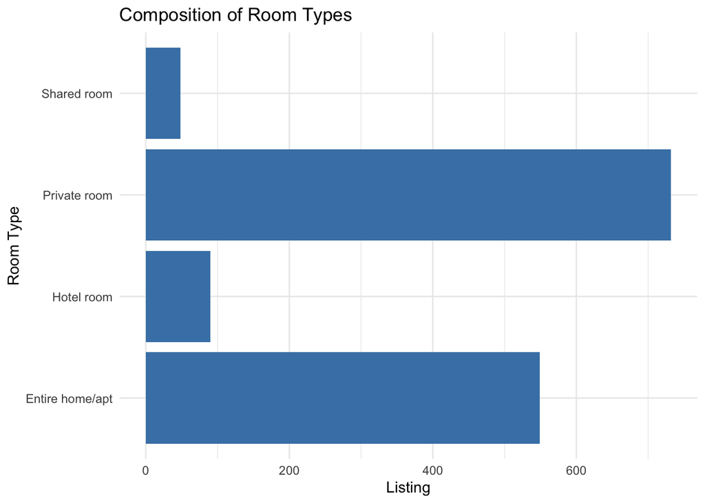

```r
ggplot(data=Singapore_train,aes(x=room_type))+geom_bar(fill="steelblue")+
  labs(title = "Composition of Room Types",
       x="Room Type",
       y="Listing")+
  theme_minimal()+
  coord_flip()
```

Airbnb hosts can list entire homes/apartments, private/shared rooms, and hotel rooms. Depending on the room type and activity, a residential Airbnb listing could be more like a hotel, disruptive for neighbours, taking away housing, and illegal.

We can see that most of the listings are private room and entire home/apartment, while the numbers of hotel room and shared room are relatively lower

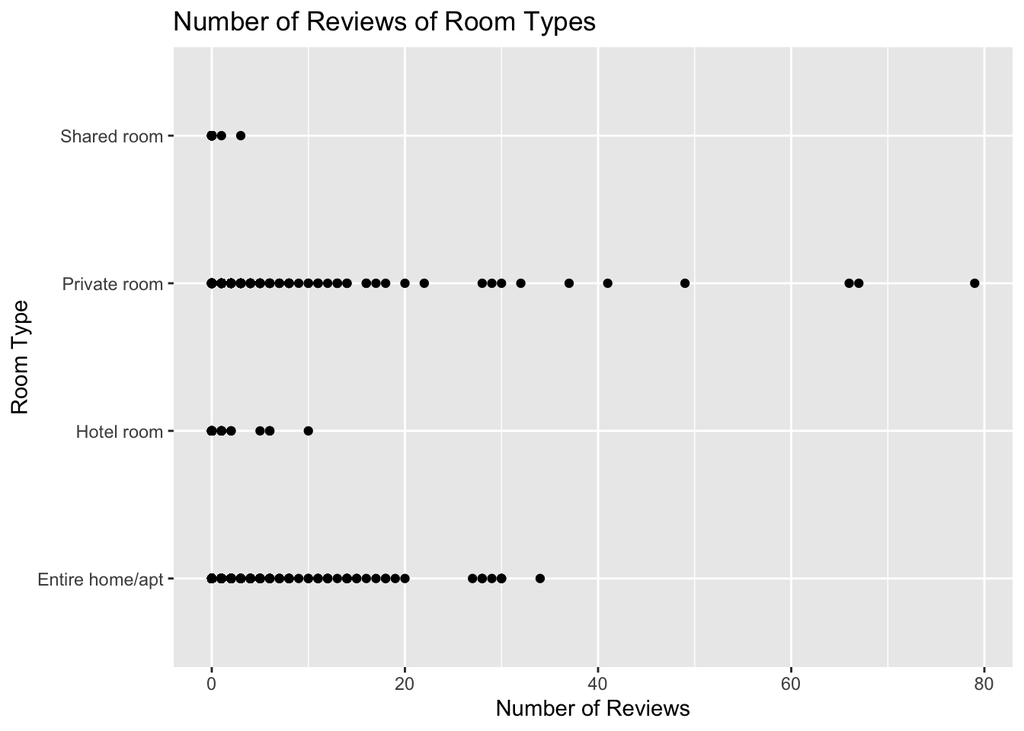

```r
ggplot(Singapore_train, aes(x = number_of_reviews_ltm, y = room_type)) +
  labs(title = "Number of Reviews of Room Types",
       x="Number of Reviews",
       y="Room Type")+
    geom_point()
```

Similar to the pattern of composition of room types, the numbers of reviews in the last 12 months of private room and entire home/apartment are much higher than that of shared room and hotel room. Also, the numbers of reviews of most listings are less than 20, and only a small part of private rooms and entire home/apartment have reviews more than 20 in the last year.

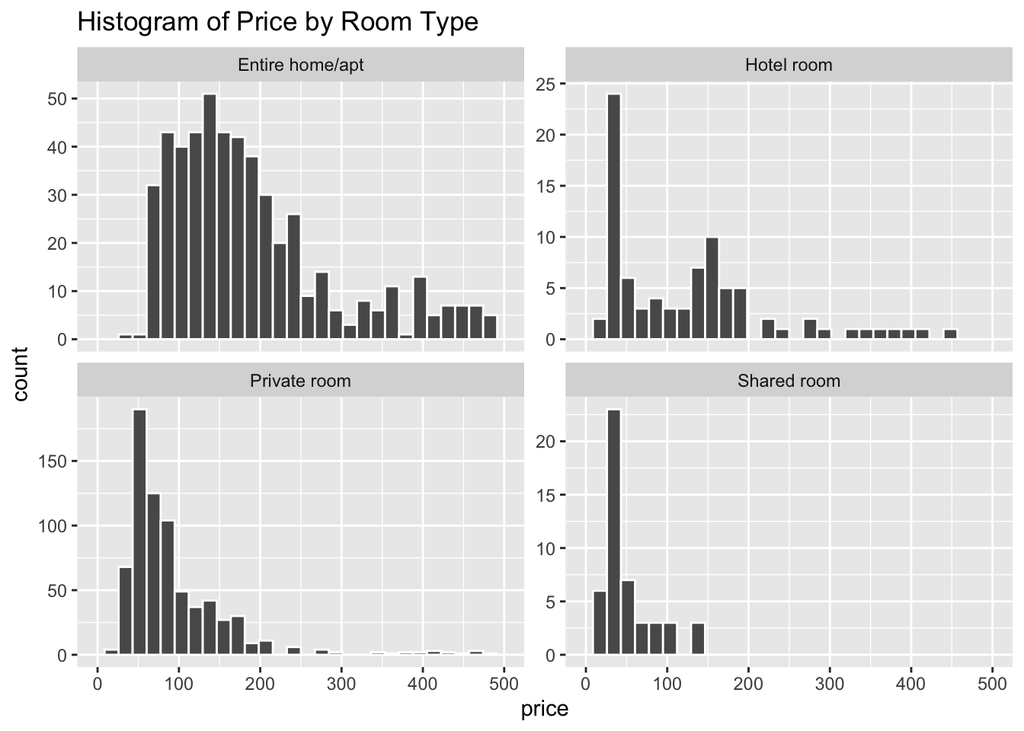

```r
ggplot(Singapore_train, aes(price)) +
  geom_histogram(bins = 30, color = "white") +
  facet_wrap(~room_type, scales = "free_y") +
  xlim(0,500)+
  labs(
    title = "Histogram of Price by Room Type"
  )
```

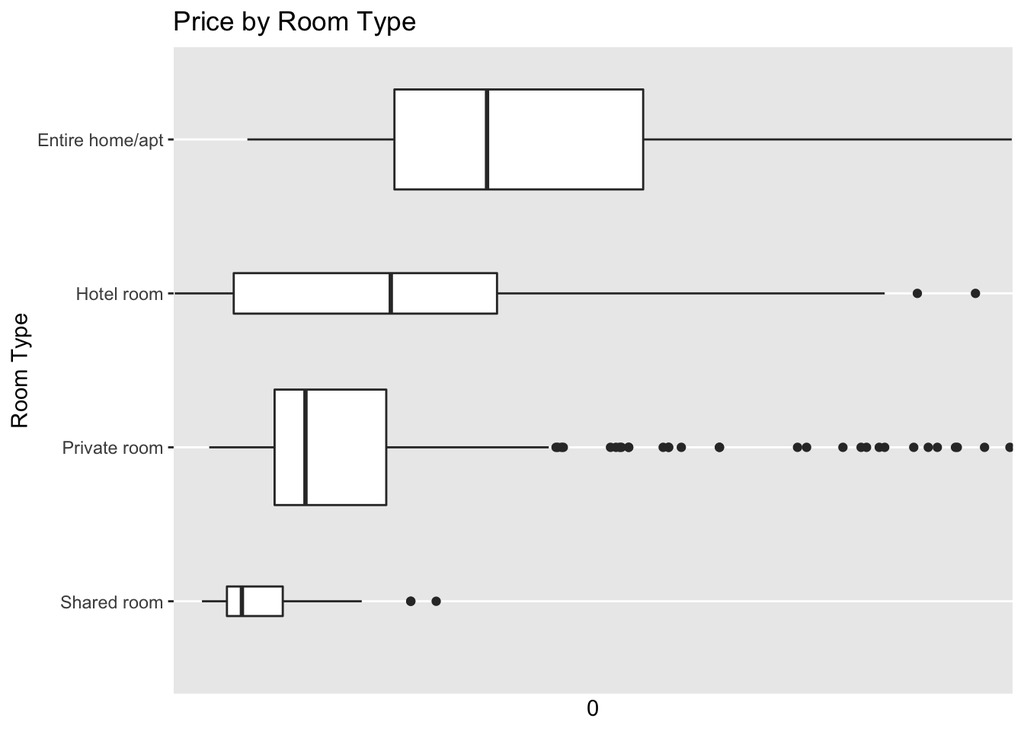

```r
ggplot(Singapore_train, aes(reorder(room_type, price), price)) +
  geom_boxplot(varwidth = TRUE)+
  scale_y_discrete(0,200)+
  coord_flip()+
  labs(
    title = "Price by Room Type",
    x = "Room Type",
    y="Price")
```

I think it’s because of the diversity of entire home/apartment and hotel room, that they can vary from many factors, such as sizes and locations, and this reason also decides their higher prices. On the other hand, the size of private rooms shared rooms are much smaller, and so are their privacy, therefore their prices vary less from each listings and are relatively lower.

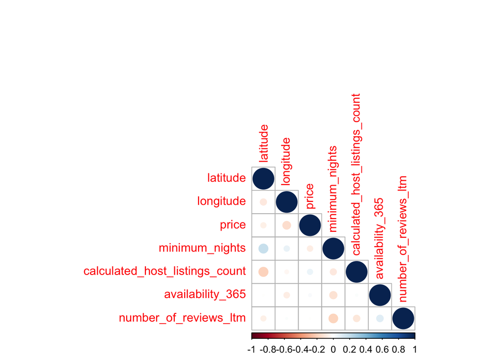

```r
Singapore_train %>%
  select(is.numeric,-id,-host_id,-reviews_per_month,-number_of_reviews) %>%
  cor() %>%
  corrplot(type = "lower")
```

We can see that almost every variable is not correlated to each other, which makes sense since the most important factors that affects a listing’s price and reviews are its size, location, cleanliness, etc.

# Fit a linear regression model

```r
set.seed(1202)

lm_spec <- linear_reg() %>%
  set_mode("regression") %>%
  set_engine("lm")

lm_fit<-lm_spec %>%
  fit(number_of_reviews_ltm~latitude+longitude+minimum_nights+
        price+calculated_host_listings_count+availability_365,
      data=Singapore_train)

augment(lm_fit,new_data=Singapore_train) %>%
  rmse(truth=number_of_reviews_ltm,estimate=.pred)
```

```
## # A tibble: 1 × 3
##   .metric .estimator .estimate
##   <chr>   <chr>          <dbl>
## 1 rmse    standard        5.14
```

```r
augment(lm_fit,new_data=Singapore_test) %>%
  rmse(truth=number_of_reviews_ltm,estimate=.pred)
```

```
## # A tibble: 1 × 3
##   .metric .estimator .estimate
##   <chr>   <chr>          <dbl>
## 1 rmse    standard        4.82
```

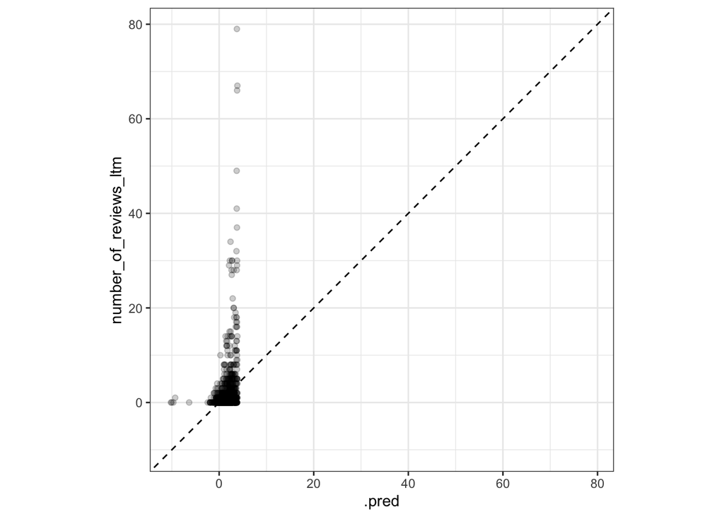

```r
Singapore_train_res<-predict(lm_fit,new_data = Singapore_train %>%
                               select(-number_of_reviews_ltm))

Singapore_train_res<-bind_cols(Singapore_train_res,Singapore_train %>%
                                 select(number_of_reviews_ltm))

Singapore_train_res %>%
  ggplot(aes(x= .pred,y=number_of_reviews_ltm))+
  geom_point(alpha=0.2)+
  geom_abline(lty=2)+
  theme_bw()+
  coord_obs_pred()
```

We can see that the model didn’t do well, since if it did well, the dots would form a straight line.

# Fit a polynomial regression model

```r
Singapore_recipe <-recipe(number_of_reviews_ltm~price,
                          data = Singapore_train) %>%
  step_poly(price,degree=2)

poly_wf<-workflow() %>%
  add_recipe(Singapore_recipe) %>%
  add_model(lm_spec)

poly_fit<-fit(poly_wf,data=Singapore_train)

augment(poly_fit,new_data = Singapore_train) %>%
  rmse(truth=number_of_reviews_ltm,estimate=.pred)
```

```
## # A tibble: 1 × 3
##   .metric .estimator .estimate
##   <chr>   <chr>          <dbl>
## 1 rmse    standard        5.29
```

```r
augment(poly_fit,new_data = Singapore_test) %>%
  rmse(truth=number_of_reviews_ltm,estimate=.pred)
```

```
## # A tibble: 1 × 3
##   .metric .estimator .estimate
##   <chr>   <chr>          <dbl>
## 1 rmse    standard        4.84
```

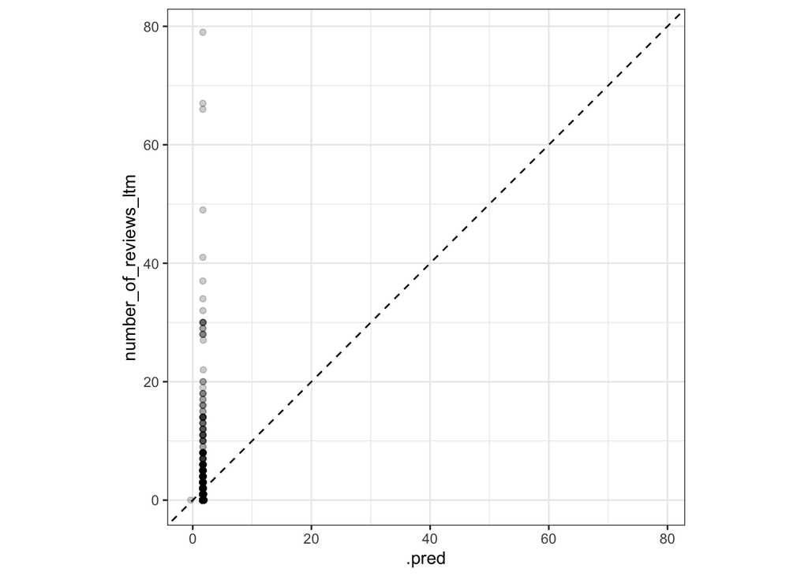

```r
Singapore_train_res<-predict(poly_fit,new_data = Singapore_train %>%
                               select(-number_of_reviews_ltm))

Singapore_train_res<-bind_cols(Singapore_train_res,Singapore_train %>%
                                 select(number_of_reviews_ltm))

Singapore_train_res %>%
  ggplot(aes(x= .pred,y=number_of_reviews_ltm))+
  geom_point(alpha=0.2)+
  geom_abline(lty=2)+
  theme_bw()+
  coord_obs_pred()
```

Similarly, the model didn’t do well.

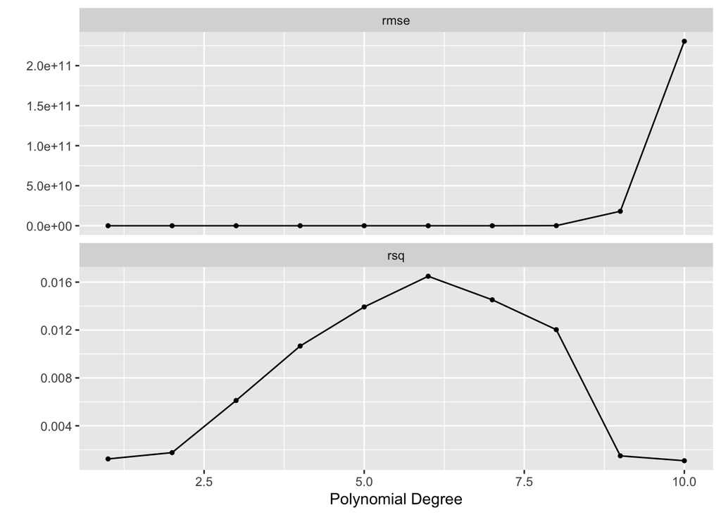

```r
poly_tuned_rec<-recipe(number_of_reviews_ltm ~ price, data = Singapore_train) %>%
  step_poly(price, degree = tune())

poly_tuned_wf <- workflow() %>%
  add_recipe(poly_tuned_rec) %>%
  add_model(lm_spec)


train_folds <- vfold_cv(Singapore_train,v=10)

degree_grid <- grid_regular(degree(range = c(1, 10)), levels = 10)

tune_res <- tune_grid(
  object = poly_tuned_wf,
  resamples = train_folds,
  grid = degree_grid
)

autoplot(tune_res)
```

We want it to only show the best performing models

```r
show_best(tune_res,metric="rmse")
```

```
## # A tibble: 5 × 7
##   degree .metric .estimator    mean     n  std_err .config
##    <dbl> <chr>   <chr>        <dbl> <int>    <dbl> <chr>
## 1      1 rmse    standard      5.06    10    0.523 Preprocessor01_Model1
## 2      2 rmse    standard      5.56    10    0.723 Preprocessor02_Model1
## 3      3 rmse    standard     30.5     10   25.4   Preprocessor03_Model1
## 4      4 rmse    standard    437.      10  432.    Preprocessor04_Model1
## 5      5 rmse    standard   6021.      10 6016.    Preprocessor05_Model1
```

From the output we can see that it selected degree=1

```r
select_by_one_std_err(tune_res, degree, metric = "rmse")
```

```
## # A tibble: 1 × 9
##   degree .metric .estimator  mean     n std_err .config             .best .bound
##    <dbl> <chr>   <chr>      <dbl> <int>   <dbl> <chr>               <dbl>  <dbl>
## 1      1 rmse    standard    5.06    10   0.523 Preprocessor01_Mod…  5.06   5.58
```

```r
best_degree <- select_by_one_std_err(tune_res, degree, metric = "rmse")
final_wf <- finalize_workflow(poly_wf, best_degree)
```

Now we fit the workflow and guarantee that it is fitted on the training data set and testing data set. Then we can assess its accuracy.

```r
final_fit <- fit(final_wf, Singapore_train)
augment(final_fit, new_data = Singapore_train) %>%
  rmse(truth = number_of_reviews_ltm, estimate = .pred)
```

```
## # A tibble: 1 × 3
##   .metric .estimator .estimate
##   <chr>   <chr>          <dbl>
## 1 rmse    standard        5.29
```

```r
augment(final_fit, new_data = Singapore_test) %>%
  rmse(truth = number_of_reviews_ltm, estimate = .pred)
```

```
## # A tibble: 1 × 3
##   .metric .estimator .estimate
##   <chr>   <chr>          <dbl>
## 1 rmse    standard        4.84
```

# Fit a ridge regresion model

Visualize how the magnitude of the coefficients are being regularized towards zero as the penalty goes up.

```r
ridge_spec <- linear_reg(mixture = 0, penalty = 0) %>%
  set_mode("regression") %>%
  set_engine("glmnet")

ridge_fit <- fit(ridge_spec, number_of_reviews_ltm ~ .,data = Singapore_train)

tidy(ridge_fit)
```

```
## # A tibble: 756 × 3
##    term                   estimate penalty
##    <chr>                     <dbl>   <dbl>
##  1 (Intercept)            3.90e+ 2       0
##  2 id                    -2.20e-17       0
##  3 host_id                4.57e- 9       0
##  4 host_nameAaron         0              0
##  5 host_nameAbba          0              0
##  6 host_nameAbby          0              0
##  7 host_nameAccomodation -7.24e- 1       0
##  8 host_nameAden          1.83e+ 0       0
##  9 host_nameAdi          -9.59e- 1       0
## 10 host_nameAdrian        1.42e+ 0       0
## # … with 746 more rows
```

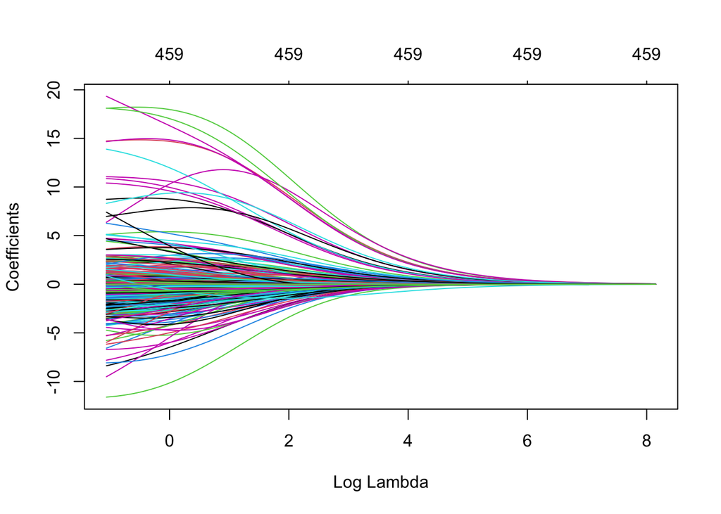

```r
ridge_fit %>%
  extract_fit_engine() %>%
  plot(xvar = "lambda")
```

Create a recipe

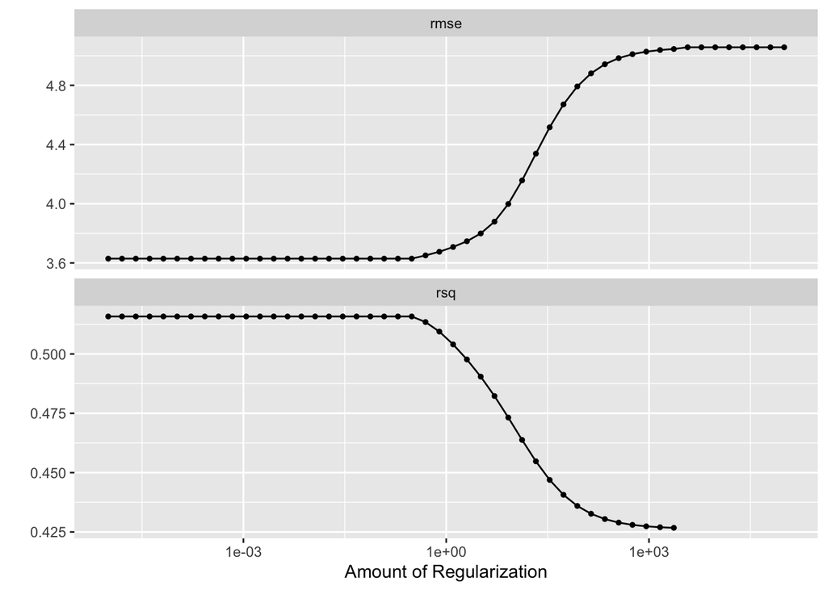

```r
ridge_recipe <-
  recipe(formula = number_of_reviews_ltm ~ ., data = Singapore_train) %>%
  step_novel(all_nominal_predictors()) %>%
  step_dummy(all_nominal_predictors()) %>%
  step_zv(all_predictors()) %>%
  step_normalize(all_predictors())

ridge_spec <-
  linear_reg(penalty = tune(), mixture = 0) %>%
  set_mode("regression") %>%
  set_engine("glmnet")

ridge_workflow <- workflow() %>%
  add_recipe(ridge_recipe) %>%
  add_model(ridge_spec)

penalty_grid <- grid_regular(penalty(range = c(-5, 5)), levels = 50)

tune_res <- tune_grid(
  ridge_workflow,
  resamples = train_folds,
  grid = penalty_grid
)
autoplot(tune_res)
```

It’s fairly clear that the amount of regularization have different influences on the performance metrics.

Find the best model, and apply it on the training and testing data set to validate its performance.

```r
collect_metrics(tune_res)
```

```
## # A tibble: 100 × 7
##      penalty .metric .estimator  mean     n std_err .config
##        <dbl> <chr>   <chr>      <dbl> <int>   <dbl> <chr>
##  1 0.00001   rmse    standard   3.63     10  0.229  Preprocessor1_Model01
##  2 0.00001   rsq     standard   0.516    10  0.0554 Preprocessor1_Model01
##  3 0.0000160 rmse    standard   3.63     10  0.229  Preprocessor1_Model02
##  4 0.0000160 rsq     standard   0.516    10  0.0554 Preprocessor1_Model02
##  5 0.0000256 rmse    standard   3.63     10  0.229  Preprocessor1_Model03
##  6 0.0000256 rsq     standard   0.516    10  0.0554 Preprocessor1_Model03
##  7 0.0000409 rmse    standard   3.63     10  0.229  Preprocessor1_Model04
##  8 0.0000409 rsq     standard   0.516    10  0.0554 Preprocessor1_Model04
##  9 0.0000655 rmse    standard   3.63     10  0.229  Preprocessor1_Model05
## 10 0.0000655 rsq     standard   0.516    10  0.0554 Preprocessor1_Model05
## # … with 90 more rows
```

```r
best_penalty <- select_best(tune_res, metric = "rsq")
ridge_final <- finalize_workflow(ridge_workflow, best_penalty)
ridge_final_fit <- fit(ridge_final, data = Singapore_train)
augment(ridge_final_fit, new_data = Singapore_train) %>%
  rsq(truth = number_of_reviews_ltm, estimate = .pred)
```

```
## # A tibble: 1 × 3
##   .metric .estimator .estimate
##   <chr>   <chr>          <dbl>
## 1 rsq     standard       0.794
```

```r
augment(ridge_final_fit, new_data = Singapore_test) %>%
  rsq(truth = number_of_reviews_ltm, estimate = .pred)
```

```
## # A tibble: 1 × 3
##   .metric .estimator .estimate
##   <chr>   <chr>          <dbl>
## 1 rsq     standard       0.445
```

# Fit a lasso regression model

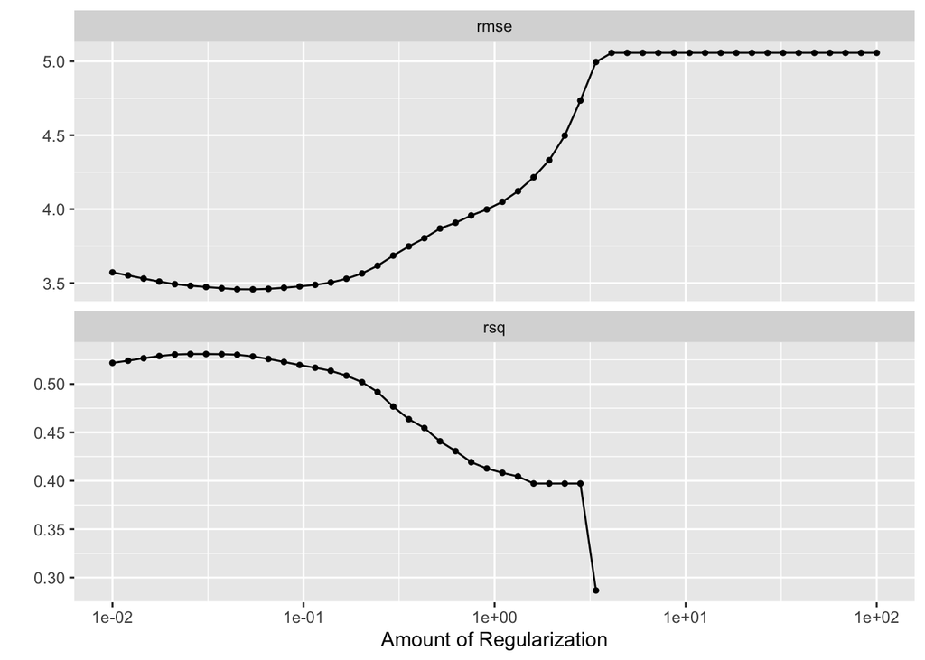

```r
lasso_recipe <-
  recipe(formula = number_of_reviews_ltm ~ .,data = Singapore_train) %>%
  step_novel(all_nominal_predictors()) %>%
  step_dummy(all_nominal_predictors()) %>%
  step_zv(all_predictors()) %>%
  step_normalize(all_predictors())

lasso_spec <-
  linear_reg(penalty = tune(), mixture = 1) %>%
  set_mode("regression") %>%
  set_engine("glmnet")

lasso_workflow <- workflow() %>%
  add_recipe(lasso_recipe) %>%
  add_model(lasso_spec)

penalty_grid <- grid_regular(penalty(range = c(-2, 2)), levels = 50)

tune_res <- tune_grid(
  lasso_workflow,
  resamples = train_folds,
  grid = penalty_grid
)

autoplot(tune_res)
```

Select the best value of penalty, find the best model and predict on the traning and testing data set.

```r
best_penalty <- select_best(tune_res, metric = "rsq")
lasso_final <- finalize_workflow(lasso_workflow, best_penalty)
lasso_final_fit <- fit(lasso_final, data = Singapore_train)
augment(lasso_final_fit, new_data = Singapore_train) %>%
  rsq(truth = number_of_reviews_ltm, estimate = .pred)
```

```
## # A tibble: 1 × 3
##   .metric .estimator .estimate
##   <chr>   <chr>          <dbl>
## 1 rsq     standard       0.798
```

```r
augment(lasso_final_fit, new_data = Singapore_test) %>%
  rsq(truth = number_of_reviews_ltm, estimate = .pred)
```

```
## # A tibble: 1 × 3
##   .metric .estimator .estimate
##   <chr>   <chr>          <dbl>
## 1 rsq     standard       0.470
```

# Fit a regression tree model

```r
tree_spec <- decision_tree() %>%
  set_engine("rpart")
reg_tree_spec <- tree_spec %>%
  set_mode("regression")
reg_tree_fit <- fit(reg_tree_spec,number_of_reviews_ltm ~ .,
                    data=Singapore_train)
augment(reg_tree_fit, new_data = Singapore_train) %>%
  rmse(truth = number_of_reviews_ltm, estimate = .pred)
```

```
## # A tibble: 1 × 3
##   .metric .estimator .estimate
##   <chr>   <chr>          <dbl>
## 1 rmse    standard        2.41
```

```r
augment(reg_tree_fit, new_data = Singapore_test) %>%
  rmse(truth = number_of_reviews_ltm, estimate = .pred)
```

```
## # A tibble: 1 × 3
##   .metric .estimator .estimate
##   <chr>   <chr>          <dbl>
## 1 rmse    standard        4.05
```

Show the regression decision tree

[figure not shown]

```r
reg_tree_fit %>%
  extract_fit_engine() %>%
  rpart.plot()
```

Find the best performing decision tree

```r
reg_tree_wf <- workflow() %>%
  add_model(reg_tree_spec %>% set_args(cost_complexity = tune())) %>%
  add_formula(number_of_reviews_ltm ~ .)

set.seed(1202)
ames_fold <- vfold_cv(Singapore_train)

param_grid <- grid_regular(cost_complexity(range = c(-4, -1)), levels = 10)

tune_res <- tune_grid(
  reg_tree_wf,
  resamples = ames_fold,
  grid = param_grid
)
```

Visualize the result

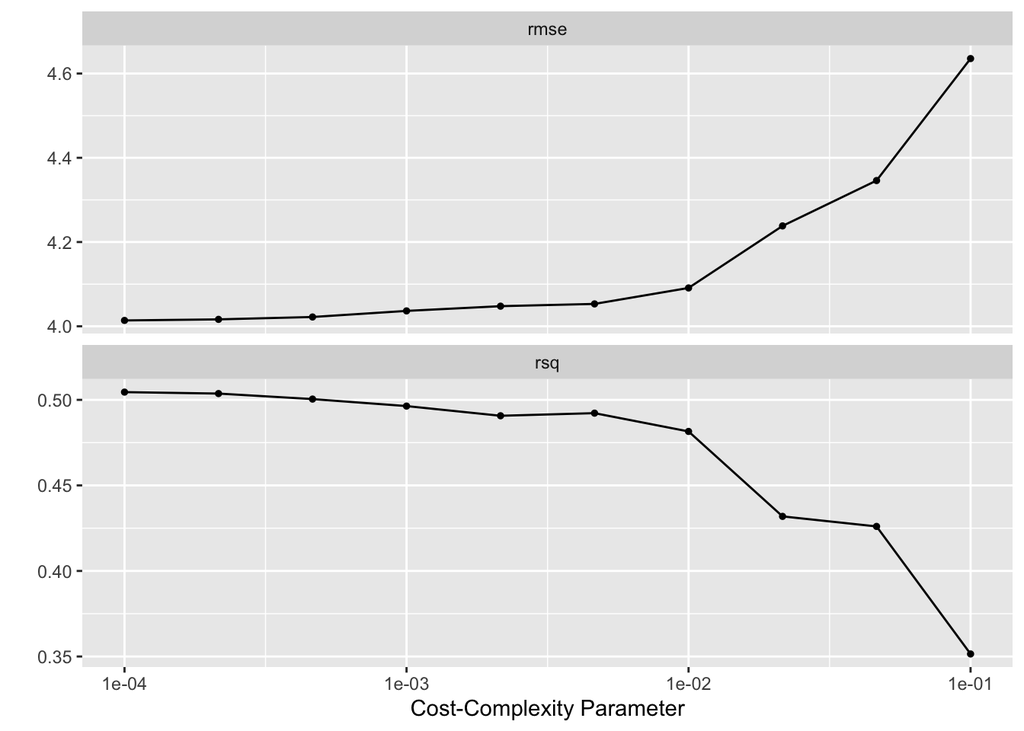

```r
autoplot(tune_res)
```

Now select the best-performing model based on rmse, and fit the final model on the whole training data set. Then visualize the model to see the tree.

[figure not shown]

```r
best_complexity <- select_best(tune_res, metric = "rmse")
reg_tree_final <- finalize_workflow(reg_tree_wf, best_complexity)
reg_tree_final_fit <- fit(reg_tree_final, data = Singapore_train)
reg_tree_final_fit %>%
  extract_fit_engine() %>%
  rpart.plot()
```

Check the performance on both training and testing data set

```r
augment(reg_tree_final_fit, new_data = Singapore_train) %>%
  rmse(truth = number_of_reviews_ltm, estimate = .pred)
```

```
## # A tibble: 1 × 3
##   .metric .estimator .estimate
##   <chr>   <chr>          <dbl>
## 1 rmse    standard        2.09
```

```r
augment(reg_tree_final_fit, new_data = Singapore_test) %>%
  rmse(truth = number_of_reviews_ltm, estimate = .pred)
```

```
## # A tibble: 1 × 3
##   .metric .estimator .estimate
##   <chr>   <chr>          <dbl>
## 1 rmse    standard        4.08
```

# Fit a SVM model

```r
svm_linear_spec <- svm_poly(degree = 1) %>%
  set_mode("regression") %>%
  set_engine("kernlab", scaled = FALSE)

svm_linear_fit <- svm_linear_spec %>%
  set_args(cost = 10) %>%
  fit(number_of_reviews_ltm ~ ., data = Singapore_train)
svm_linear_fit
```

```
## parsnip model object
##
## Support Vector Machine object of class "ksvm"
##
## SV type: eps-svr  (regression)
##  parameter : epsilon = 0.1  cost C = 10
##
## Polynomial kernel function.
##  Hyperparameters : degree =  1  scale =  1  offset =  1
##
## Number of Support Vectors : 1419
##
## Objective Function Value : -1.44543e+29
## Training error : 2.36323735731311e+53
```

```r
svm_model <-svm_poly(
    cost = tune(),
    mode = "regression") %>%
  set_engine("kernlab")

svm_workflow <- workflow() %>%
  add_model(svm_model) %>%
  add_recipe(Singapore_recipe)

set.seed(1202)

Singapore_grid_svm <- grid_regular(cost(range = c(-3, -1)), levels = 10)

Singapore_results_svm <- svm_workflow %>%
    tune_grid(resamples=train_folds, grid=Singapore_grid_svm)
```

Visualize the result

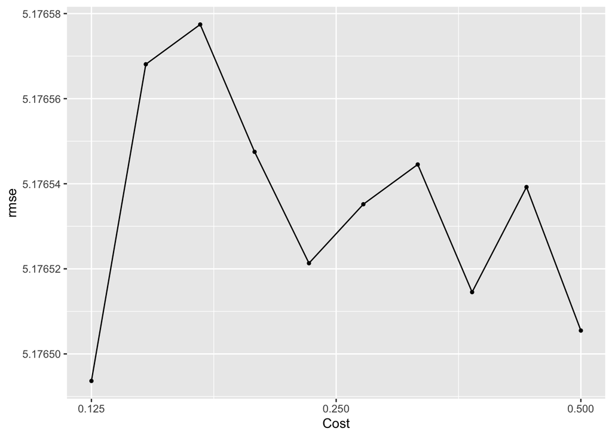

```r
autoplot(Singapore_results_svm, metric = "rmse")
```

```r
show_best(Singapore_results_svm, metric = "rmse")
```

```
## # A tibble: 5 × 7
##    cost .metric .estimator  mean     n std_err .config
##   <dbl> <chr>   <chr>      <dbl> <int>   <dbl> <chr>
## 1 0.125 rmse    standard    5.18    10   0.539 Preprocessor1_Model01
## 2 0.5   rmse    standard    5.18    10   0.539 Preprocessor1_Model10
## 3 0.367 rmse    standard    5.18    10   0.539 Preprocessor1_Model08
## 4 0.231 rmse    standard    5.18    10   0.539 Preprocessor1_Model05
## 5 0.270 rmse    standard    5.18    10   0.539 Preprocessor1_Model06
```

```r
Singapore_spec_svm <- svm_poly(cost=0.4286220) %>%
    set_engine("kernlab")%>%
    set_mode("regression")
Singapore_fit_svm <- workflow() %>%
    add_recipe(Singapore_recipe) %>%
    add_model(Singapore_spec_svm)%>%
    fit(data=Singapore_train)
Singapore_summary_svm <- Singapore_fit_svm %>%
    predict(Singapore_test) %>%
    bind_cols(Singapore_test) %>%
    metrics(truth=number_of_reviews_ltm, estimate=.pred) %>%
    filter(.metric=="rmse")
Singapore_summary_svm
```

```
## # A tibble: 1 × 3
##   .metric .estimator .estimate
##   <chr>   <chr>          <dbl>
## 1 rmse    standard        4.96
```

Visualize the performance on both training and testing data set

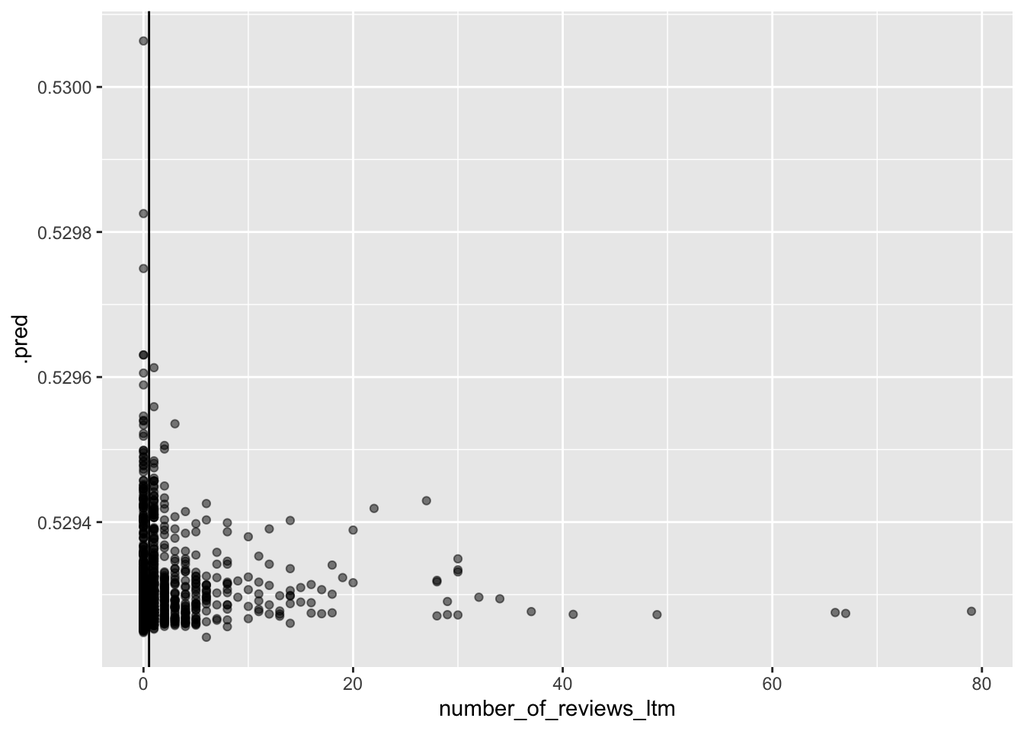

```r
augment(Singapore_fit_svm, new_data = Singapore_train) %>%
  ggplot(aes(number_of_reviews_ltm, .pred)) +
  geom_abline() +
  geom_point(alpha = 0.5)
```

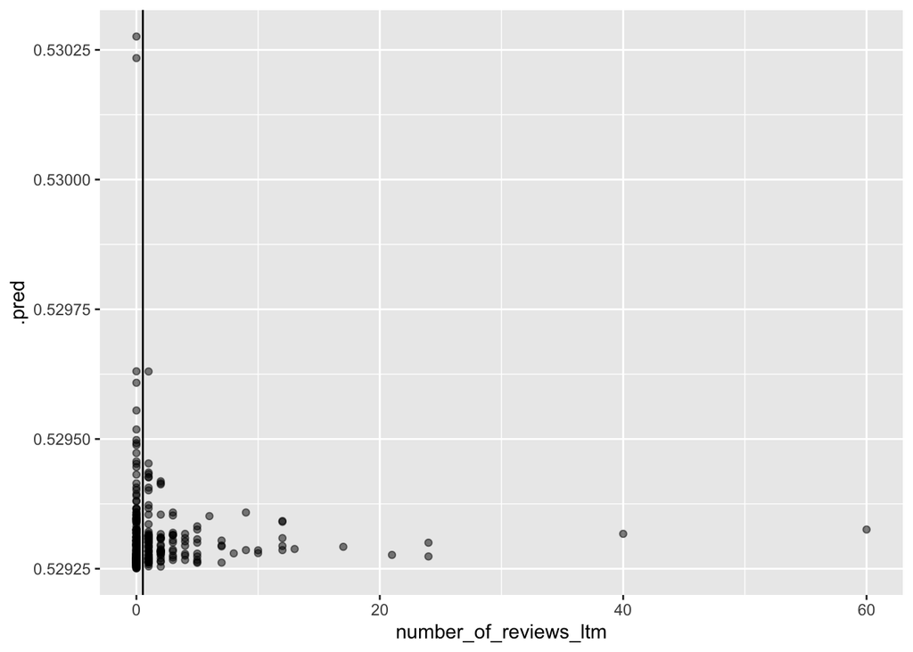

```r
augment(Singapore_fit_svm, new_data = Singapore_test) %>%
  ggplot(aes(number_of_reviews_ltm, .pred)) +
  geom_abline() +
  geom_point(alpha = 0.5)
```

# Fit a random forest model

```r
rf_model <- rand_forest(
    mtry = tune(),
    mode = "regression") %>%
  set_engine("ranger")

rf_workflow <- workflow() %>%
  add_model(rf_model) %>%
  add_recipe(Singapore_recipe)

set.seed(1202)

Singapore_grid_rf <- tibble(mtry=seq(from=1, to=10, by=2))

Singapore_results_rf <- rf_workflow %>%
    tune_grid(resamples=train_folds, grid=Singapore_grid_rf)
```

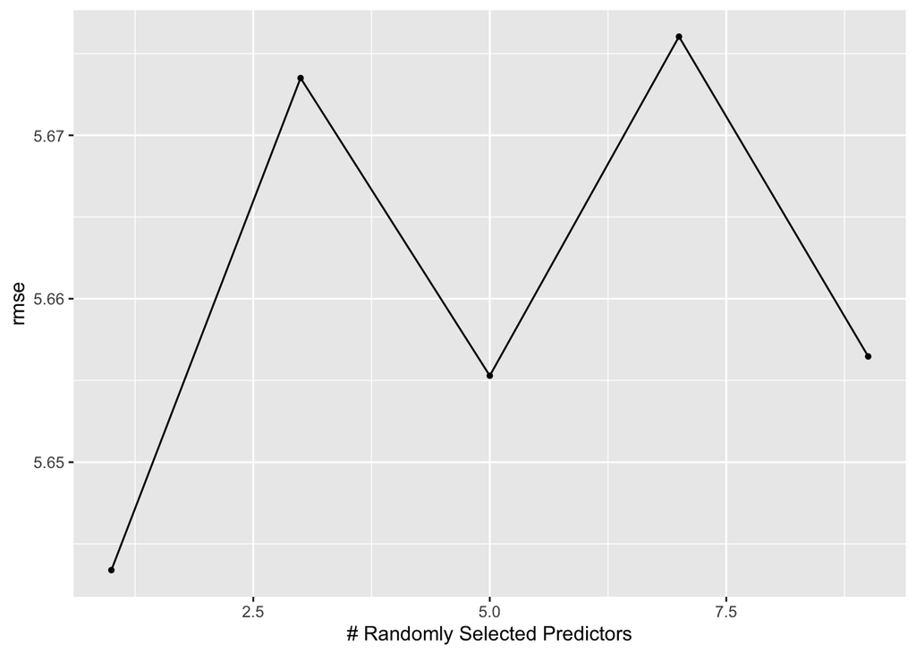

```r
autoplot(Singapore_results_rf, metric = "rmse")
```

```r
show_best(Singapore_results_rf, metric = "rmse")
```

```
## # A tibble: 5 × 7
##    mtry .metric .estimator  mean     n std_err .config
##   <dbl> <chr>   <chr>      <dbl> <int>   <dbl> <chr>
## 1     1 rmse    standard    5.64    10   0.455 Preprocessor1_Model1
## 2     5 rmse    standard    5.66    10   0.454 Preprocessor1_Model3
## 3     9 rmse    standard    5.66    10   0.449 Preprocessor1_Model5
## 4     3 rmse    standard    5.67    10   0.453 Preprocessor1_Model2
## 5     7 rmse    standard    5.68    10   0.447 Preprocessor1_Model4
```

```r
Singapore_spec_rf <- rand_forest(mtry=3) %>%
    set_engine("ranger")%>%
    set_mode("regression")
Singapore_fit_rf <- workflow() %>%
    add_recipe(Singapore_recipe) %>%
    add_model(Singapore_spec_rf)%>%
    fit(data=Singapore_train)
Singapore_summary_rf <- Singapore_fit_rf %>%
    predict(Singapore_test) %>%
    bind_cols(Singapore_test) %>%
    metrics(truth=number_of_reviews_ltm, estimate=.pred) %>%
    filter(.metric=="rmse")
Singapore_summary_rf
```

```
## # A tibble: 1 × 3
##   .metric .estimator .estimate
##   <chr>   <chr>          <dbl>
## 1 rmse    standard        4.94
```

Visualize the performance on both training and testing data set

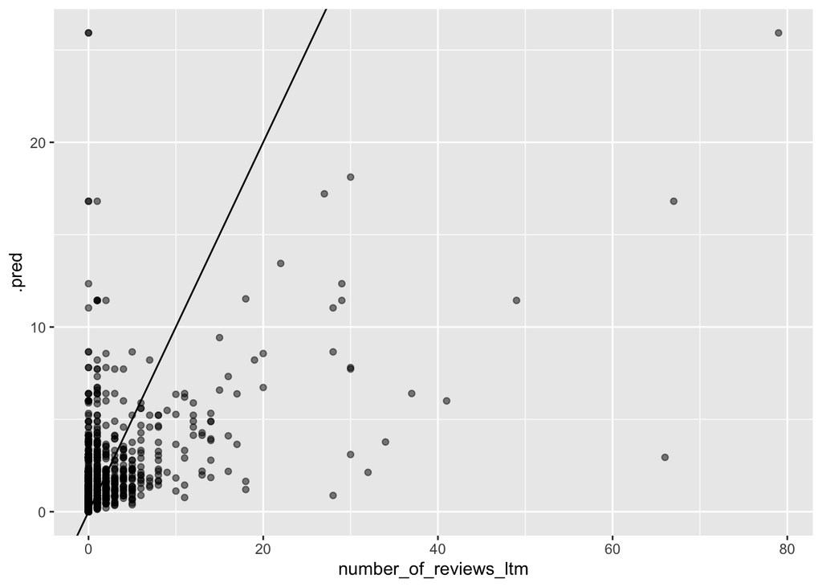

```r
augment(Singapore_fit_rf, new_data = Singapore_train) %>%
  ggplot(aes(number_of_reviews_ltm, .pred)) +
  geom_abline() +
  geom_point(alpha = 0.5)
```

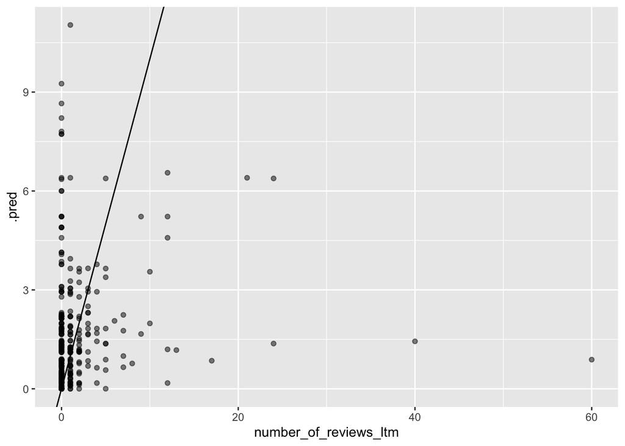

```r
augment(Singapore_fit_rf, new_data = Singapore_test) %>%
  ggplot(aes(number_of_reviews_ltm, .pred)) +
  geom_abline() +
  geom_point(alpha = 0.5)
```

# Conlcusion

Before the beginning of this project, I thought what affect the number of reviews of Airbnb the most must be its price, since I thought Airbnbs with lower price would attract more visitors, and consequently more reviews. However, after this analysis on the variables that affects the number of reviews of Airbnb in Singapore, it is clear for me to see that price does not matter that much, given the several models which I used to see how well they performed on predicting the affect of price on number of reviews.

After this course, I learned significant concepts of statistical machine learning, and I am now able to use R programming and practical packages to do exploratory data analysis, model fitting, and statistic visualization. In the future, I will continue to study in the machine learning field, and in this process, I wish I could gain more experiences of data analysis. Airbnb statistics are one of my major interests, and I will use my knowledge to analyze more complicated data set in the future.